# Description

**Prostate, Lung, Colorectal, and Ovarian Cancer Screening Trial (PLCO)** The Prostate, Lung, Colorectal, and Ovarian (PLCO) Cancer Screening Trial is a large randomized trial designed and sponsored by the National Cancer Institute (NCI) to determine the chance of getting PLCO cancer. The screening component of the trial was completed in 2006. Participants are being followed and additional data will be collected through 2015.

# General Setup

## Importing Libraries

```python
import numpy as np
import matplotlib.pyplot as plt
import pandas as pd
import tensorflow as tf
import tensorflow.keras as kr
import seaborn as sns
```

## Data Import

```python
dataset = pd.read_csv('Cancer.csv');

#Rename Feature Names for Readability
col_names=[];
for i in range(0,len(dataset.columns)):
    col_names.append('$x$' + f'${str(i)}$')
dataset.columns = col_names

#Show Dataset
dataset
```

|  | $x$$0$ | $x$$1$ | $x$$2$ | $x$$3$ | $x$$4$ | $x$$5$ | $x$$6$ | $x$$7$ | $x$$8$ | $x$$9$ | ... | $x$$3991$ | $x$$3992$ | $x$$3993$ | $x$$3994$ | $x$$3995$ | $x$$3996$ | $x$$3997$ | $x$$3998$ | $x$$3999$ | $x$$4000$ |
| --- | --- | --- | --- | --- | --- | --- | --- | --- | --- | --- | --- | --- | --- | --- | --- | --- | --- | --- | --- | --- | --- |
| 0 | 0.025409 | 0.051085 | 0.056305 | 0.021738 | 0.027410 | 0.014914 | 0.022455 | 0.023957 | 0.060527 | 0.047382 | ... | 0.055033 | 0.080864 | 0.053423 | 0.051942 | 0.013187 | 0.028573 | 0.020427 | 0.023261 | 0.019975 | C |
| 1 | 0.025536 | 0.036123 | 0.054195 | 0.009735 | 0.027521 | 0.052255 | 0.042812 | 0.069087 | 0.069873 | 0.066629 | ... | 0.033783 | 0.029022 | 0.046397 | 0.033288 | 0.041889 | 0.019256 | -0.009447 | 0.021481 | 0.025569 | C |
| 2 | 0.012817 | 0.029652 | 0.079290 | 0.050677 | 0.039737 | 0.057713 | 0.044492 | 0.034581 | 0.042587 | 0.034147 | ... | 0.036083 | 0.038598 | 0.048881 | 0.025569 | 0.026710 | 0.025122 | 0.047466 | 0.046706 | 0.043482 | C |
| 3 | 0.019846 | -0.010577 | -0.007504 | 0.019042 | 0.068786 | 0.061764 | 0.039036 | 0.020445 | 0.025988 | 0.066716 | ... | 0.032044 | 0.026320 | 0.072016 | 0.070145 | 0.055744 | 0.051084 | 0.036683 | 0.043729 | 0.040289 | C |
| 4 | 0.039048 | 0.039355 | 0.001343 | 0.026221 | 0.044091 | 0.043953 | 0.039629 | 0.047926 | 0.046892 | 0.030589 | ... | 0.065494 | 0.030681 | 0.039686 | 0.037256 | 0.022888 | 0.056221 | 0.055819 | 0.010087 | 0.006004 | C |
| ... | ... | ... | ... | ... | ... | ... | ... | ... | ... | ... | ... | ... | ... | ... | ... | ... | ... | ... | ... | ... | ... |
| 210 | 0.019997 | 0.002927 | 0.006809 | -0.003585 | 0.026362 | 0.026540 | 0.026112 | 0.026230 | 0.021676 | 0.024205 | ... | 0.018509 | 0.013225 | 0.015765 | 0.018762 | 0.012212 | 0.009340 | 0.020955 | 0.010685 | 0.013423 | N |
| 211 | 0.042346 | 0.031884 | 0.049617 | 0.031419 | 0.042043 | 0.033383 | 0.054695 | 0.079029 | 0.063147 | 0.040817 | ... | 0.019066 | 0.038845 | 0.035201 | 0.013012 | 0.032180 | 0.026465 | 0.017850 | 0.036014 | 0.018276 | N |
| 212 | 0.023558 | 0.021331 | 0.016210 | 0.012324 | 0.022074 | 0.029829 | 0.032624 | 0.022100 | 0.028950 | 0.037769 | ... | 0.031909 | 0.019024 | 0.024298 | 0.032061 | 0.009901 | 0.011709 | 0.008274 | 0.004742 | 0.024756 | N |
| 213 | 0.028351 | 0.023266 | 0.004556 | 0.024095 | 0.018943 | 0.025935 | 0.019066 | 0.037213 | 0.041892 | 0.031092 | ... | 0.012613 | 0.031370 | 0.030285 | 0.034522 | 0.024089 | 0.006737 | 0.010033 | 0.017391 | 0.031537 | N |
| 214 | 0.027428 | 0.027021 | 0.015273 | 0.026199 | 0.018178 | 0.022988 | 0.021955 | 0.044174 | 0.034616 | 0.030664 | ... | 0.040424 | 0.011187 | 0.007513 | 0.020666 | 0.040298 | 0.021256 | 0.026642 | 0.027718 | 0.040418 | N |

215 rows × 4001 columns

## Random Seed

```python
seed = 34;
```

# Data Exploration

## General Information

```python
dataset.info()
```

```
<class 'pandas.core.frame.DataFrame'>
RangeIndex: 215 entries, 0 to 214
Columns: 4001 entries, $x$$0$ to $x$$4000$
dtypes: float64(4000), object(1)
memory usage: 6.6+ MB
```

## Descriptive Statistics for each Feature

```python
dataset.describe()
```

|  | $x$$0$ | $x$$1$ | $x$$2$ | $x$$3$ | $x$$4$ | $x$$5$ | $x$$6$ | $x$$7$ | $x$$8$ | $x$$9$ | ... | $x$$3990$ | $x$$3991$ | $x$$3992$ | $x$$3993$ | $x$$3994$ | $x$$3995$ | $x$$3996$ | $x$$3997$ | $x$$3998$ | $x$$3999$ |
| --- | --- | --- | --- | --- | --- | --- | --- | --- | --- | --- | --- | --- | --- | --- | --- | --- | --- | --- | --- | --- | --- |
| count | 215.000000 | 215.000000 | 215.000000 | 215.000000 | 215.000000 | 215.000000 | 215.000000 | 215.000000 | 215.000000 | 215.000000 | ... | 215.000000 | 215.000000 | 215.000000 | 215.000000 | 215.000000 | 215.000000 | 215.000000 | 215.000000 | 215.000000 | 215.000000 |
| mean | 0.035385 | 0.034011 | 0.031153 | 0.029453 | 0.030437 | 0.031630 | 0.037983 | 0.051983 | 0.053108 | 0.043813 | ... | 0.031454 | 0.030414 | 0.026837 | 0.028083 | 0.030159 | 0.029051 | 0.030198 | 0.029265 | 0.028464 | 0.028291 |
| std | 0.020965 | 0.023742 | 0.020610 | 0.018792 | 0.017193 | 0.019584 | 0.020329 | 0.025393 | 0.025899 | 0.022097 | ... | 0.015441 | 0.016721 | 0.017868 | 0.017953 | 0.016342 | 0.014756 | 0.016783 | 0.017017 | 0.016603 | 0.016924 |
| min | -0.004115 | -0.022688 | -0.016533 | -0.006113 | -0.010742 | -0.009920 | -0.010414 | 0.006379 | 0.009280 | 0.007561 | ... | 0.005392 | 0.000822 | -0.013180 | -0.000679 | 0.002361 | -0.009846 | -0.001082 | -0.009447 | -0.000229 | -0.000048 |
| 25% | 0.022663 | 0.018208 | 0.017315 | 0.016656 | 0.020933 | 0.018883 | 0.022636 | 0.034256 | 0.036876 | 0.030309 | ... | 0.020895 | 0.018226 | 0.015529 | 0.016985 | 0.018969 | 0.018634 | 0.018542 | 0.019116 | 0.017654 | 0.017240 |
| 50% | 0.032690 | 0.029299 | 0.028017 | 0.027144 | 0.027521 | 0.028011 | 0.035989 | 0.047926 | 0.048935 | 0.038779 | ... | 0.028658 | 0.026214 | 0.023723 | 0.026230 | 0.027577 | 0.027533 | 0.027207 | 0.026541 | 0.025697 | 0.025569 |
| 75% | 0.044659 | 0.044359 | 0.042087 | 0.038161 | 0.039281 | 0.041763 | 0.049378 | 0.064891 | 0.066106 | 0.055570 | ... | 0.039772 | 0.039735 | 0.034826 | 0.036069 | 0.038600 | 0.037986 | 0.039789 | 0.036286 | 0.036866 | 0.036661 |
| max | 0.176470 | 0.132940 | 0.114660 | 0.123630 | 0.099995 | 0.120050 | 0.113420 | 0.142060 | 0.212770 | 0.167180 | ... | 0.080878 | 0.086974 | 0.113020 | 0.123710 | 0.101980 | 0.091268 | 0.093152 | 0.107750 | 0.113910 | 0.101880 |

8 rows × 4000 columns

## Data Distribution

```python
# Too Large!

# import warnings
# warnings.filterwarnings('ignore')
# with warnings.catch_warnings():      #Catch warnings in code section
#     warnings.simplefilter("ignore")
#     plt.subplots(figsize=(15,60));
#     ax = plt.gca();
#     dataset.hist(bins=30, figsize=(1,1), grid=False, layout=(90,90), sharex=False, ax=ax, alpha=0.5);
#     plt.tight_layout();
```

## Checking for Invalid Inputs

```python
print(f'There are {dataset.isnull().sum().sum()} null values in the dataset.')
print(f'There are {dataset.isna().sum().sum()} NaN values in the dataset.')

#No need to impute.
```

```
There are 0 null values in the dataset.
There are 0 NaN values in the dataset.
```

## General Correlations

```
Too many features to visualize at once!
```

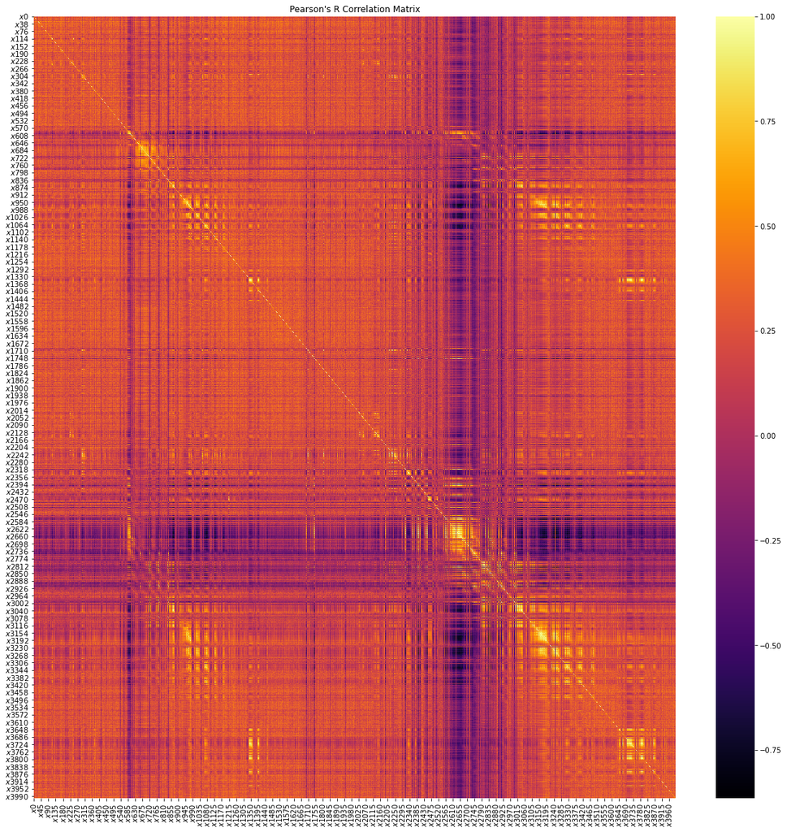

```python
corr_mat = dataset.corr(method='pearson');
#mask = np.triu(np.ones_like(corr_mat, dtype=bool));
plt.figure(dpi=300);
plt.subplots(figsize=(20,20));
plt.title("Pearson's R Correlation Matrix");
sns.heatmap(corr_mat, annot=False, lw=0, linecolor='white', cmap='inferno');
print('Too many features to visualize at once!')
```

# Data Preprocessing

## I/O Separation

```python
x = dataset.iloc[:, 1:-1].values
y = dataset.iloc[:, -1].values
# pd.DataFrame(x)
```

## Encoding Dependent Variable

```python
from sklearn.preprocessing import LabelEncoder
le = LabelEncoder();
y = le.fit_transform(y);
```

# [Part A] Principal Component Analysis (PCA)

## Get Top 2 Principal Components

```python
from sklearn.decomposition import PCA
n_comp = 2; ## bw 0<val>1 -> explained var ratio, othw: bw 0 and min(n_samples, n_features)
pca = PCA(n_components=n_comp, random_state=seed);
pca.fit(x);
print(f'Using {n_comp} Principal Components retains {round(pca.explained_variance_ratio_.sum() * 100, 3)}% of the data.')
```

```
Using 2 Principal Components retains 85.775% of the data.
```

## Transform Input Data

```python
xPC = pca.transform(x);
pd.DataFrame(xPC)
```

|  | 0 | 1 |
| --- | --- | --- |
| 0 | 9.266718 | 0.301442 |
| 1 | 19.951636 | -0.488083 |
| 2 | 12.567393 | -0.776992 |
| 3 | 29.648526 | 9.235698 |
| 4 | 22.292447 | 9.280581 |
| ... | ... | ... |
| 210 | -9.338249 | -4.617745 |
| 211 | -2.877763 | -1.046576 |
| 212 | -0.558223 | -5.645360 |
| 213 | -3.872328 | -6.608229 |
| 214 | -0.113340 | 2.167075 |

215 rows × 2 columns

## Plot of Principal Components (PC1-PC2)

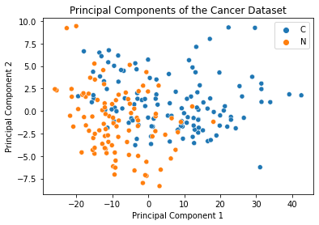

```python
y_labeled = le.inverse_transform(y);
ax1 = sns.scatterplot(x=xPC[:,0], y=xPC[:,1], hue=y_labeled);
ax1.set(title='Principal Components of the Cancer Dataset',
        ylabel='Principal Component 2',
        xlabel='Principal Component 1');
```

# [Part B] Principal Component Analysis (PCA)

## Get Top 10 Principal Components

```python
from sklearn.decomposition import PCA
n_comp = 10; ## bw 0<val>1 -> explained var ratio, othw: bw 0 and min(n_samples, n_features)
pca2 = PCA(n_components=n_comp, random_state=seed, svd_solver='full');
pca2.fit(x);
```

## Evaluate Explained Variance (Data Retention)

```python
print(f'Using {n_comp} Principal Components retains {round(pca2.explained_variance_ratio_.sum() * 100, 3)}% of the data.')
```

```
Using 10 Principal Components retains 97.216% of the data.
```

## Train/Test Split on PCs

```python
xPC = pca2.transform(x);
from sklearn.model_selection import train_test_split
x_train, x_test, y_train, y_test = train_test_split(xPC, y, test_size = 0.2, random_state = seed)
```

## Feature Scaling

```python
from sklearn.preprocessing import StandardScaler
sc = StandardScaler()
x_train = sc.fit_transform(x_train) #Fit the scaler ONLY to training data
x_test = sc.transform(x_test) #Transform (w/o fitting) the testing data
```

# Reattempting Data Exploration on Principal Components

## Data Distributions

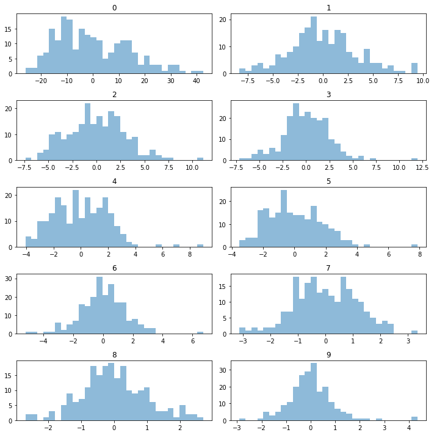

```python
pc_title=[];
for i in range(1,11):
    pc_title.append(f'Principal Component {i}');

import warnings
warnings.filterwarnings('ignore')
with warnings.catch_warnings():      #Catch warnings in code section
    warnings.simplefilter("ignore")
    plt.subplots(figsize=(10,10));
    ax = plt.gca();
    pd.DataFrame(xPC).hist(bins=30, figsize=(1,1), grid=False, layout=(5,2), sharex=False, ax=ax, alpha=0.5);
    plt.tight_layout();
```

The first 10 Principal Components are observed to be not identically distributed, so we expect gaussian methods or Bayesian to perform poorly. Similarly, it can be seen that not all PCs are approximately normally distributed.

## General Correlations

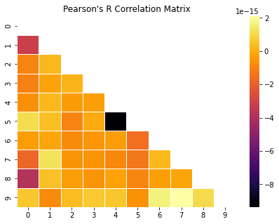

```python
corr_mat = pd.DataFrame(xPC).corr(method='pearson');
mask = np.triu(np.ones_like(corr_mat, dtype=bool));
plt.figure(dpi=300);
plt.subplots(figsize=(7,5));
plt.title("Pearson's R Correlation Matrix");
sns.heatmap(corr_mat, annot=False, lw=0.5, linecolor='white', cmap='inferno', mask=mask);
```

Interestingly, it can be seen that there is negligible correlation between the first 10 principal components.

# [Part C] Artificial Neural Network (ANN) Model

## Build and Compile the Model

```python
ANNmodel = kr.models.Sequential([
    kr.layers.Dense(10, activation='relu'),
    kr.layers.Dropout(0.2),
    kr.layers.Dense(5, activation='relu'),
    kr.layers.Dense(1, activation='sigmoid')
    ])

#Compile
ANNmodel.compile(optimizer = 'sgd', loss = 'binary_crossentropy', metrics = ['accuracy']);
```

## Fit Model with Early Stopping

```python
#Callbacks
from keras.callbacks import EarlyStopping
es = EarlyStopping(monitor='accuracy', mode='max', verbose=1, patience=50)

#Fit
ANNmodel.fit(x_train, y_train, batch_size = 50, epochs = 100, verbose=0, callbacks=es);
```

## Evaluate the Model

```python
loacc = ANNmodel.evaluate(x=x_test, y=y_test, verbose=0);
lab = ANNmodel.metrics_names;
for i in range(0,len(lab)):
    print(f'Model\'s {lab[i]} is {round(loacc[i], 4)}.')
```

```
Model's loss is 0.412.
Model's accuracy is 0.9302.
```

# Model Optimization

```python
from sklearn.model_selection import GridSearchCV
from tensorflow.keras.wrappers.scikit_learn import KerasClassifier
```

The following code is commented out due to long run times, but the results are printed below.

```
#Suppress warnings for non-convergent ANN models
tf.compat.v1.logging.set_verbosity(tf.compat.v1.logging.ERROR)

from sklearn.model_selection import GridSearchCV
from tensorflow.keras.wrappers.scikit_learn import KerasClassifier

# Function to create model, required for KerasClassifier
def create_model(optimizer='adam', epochs=100, batch_size=50, neurons=10):
    # create model
    model = kr.models.Sequential([
                                  kr.layers.Dense(neurons, activation='relu'),
                                  kr.layers.Dropout(0.2),
                                  kr.layers.Dense(neurons/2, activation='relu'),
                                  kr.layers.Dense(1, activation='sigmoid')
                                ])

    # Compile model
    model.compile(loss='binary_crossentropy', optimizer=optimizer, metrics=['accuracy'])
    return model;

# create model and pass all arguments to be optimized
model = (KerasClassifier(build_fn=create_model, epochs=50, batch_size=50, verbose=0));

# Define all parameters to be searched for in grid
param_grid = {
              'epochs' : [100, 75, 50, 25],
              'batch_size': [25, 50, 100],
              'optimizer' : ['adam', 'sgd'],
              'neurons' : [10, 15, 20, 25]
             }

# Create the GridSearchCV object
grid = GridSearchCV(estimator=model, param_grid=param_grid, n_jobs=-1);

# Fit to data
grid_result = grid.fit(x_train, y_train);

#Print results
print("Best Accuracy: %f using %s" % (round(grid_result.best_score_ * 100,3), grid_result.best_params_));
```

**Best Accuracy: 97.092000 using {'batch_size': 25, 'epochs': 100, 'neurons': 25, 'optimizer': 'adam'}**

# Comparing to Other Models

```python
models = [];
```

## Optimized ANN Model

```python
def create_model(optimizer='adam', epochs=100, batch_size=50, neurons=10):
    # create model
    model = kr.models.Sequential([
                                  kr.layers.Dense(neurons, activation='relu'),
                                  kr.layers.Dropout(0.2),
                                  kr.layers.Dense(neurons/2, activation='relu'),
                                  kr.layers.Dense(1, activation='sigmoid')
                                ])

    # Compile model
    model.compile(loss='binary_crossentropy', optimizer=optimizer, metrics=['accuracy'])
    return model;

ANNmodelOptimized = create_model(optimizer='adam', epochs=100, batch_size=25, neurons=25);
ANNmodelOptimized.fit(x_train, y_train, epochs=100, batch_size=25, callbacks=es, verbose=0);

models.append(('ANN', ANNmodelOptimized));

#Wrap model for use with SKLearn tools
models[0] = ('ANN', KerasClassifier(build_fn=create_model, epochs=100, batch_size=25, verbose=0, neurons=25, optimizer='adam'));
```

## Additional Models

### Logistic Regression (LR)

```python
from sklearn.linear_model import LogisticRegression
LRmodel = LogisticRegression(solver='newton-cg'); #Use this solver to avoid convergence issues with lbfgs
LRmodel.fit(x_train, y_train);
models.append(('LR',LRmodel));
```

### Random Forest

```python
from sklearn.ensemble import RandomForestClassifier
RFCmodel = RandomForestClassifier(n_estimators=100); #N_estimators and criterion can be optimized.
RFCmodel.fit(x_train, y_train);
models.append(('RF', RFCmodel));
```

### Gaussian Naive Bayes

```python
from sklearn.naive_bayes import GaussianNB
gaussNBmodel = GaussianNB(); #Epsilon can be optimized?
gaussNBmodel.fit(x_train, y_train);
models.append(('NB', gaussNBmodel));
```

### KNN

```python
from sklearn.neighbors import KNeighborsClassifier
KNNmodel = KNeighborsClassifier(n_neighbors=5, p=2); #K can be optimized
KNNmodel.fit(x_train, y_train);
models.append(('KNN', KNNmodel));
```

# Model Performance Comparison

## Via Confusion Matrices

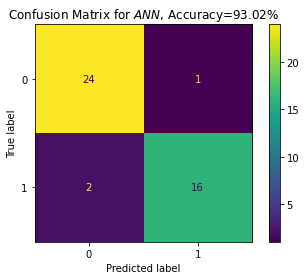

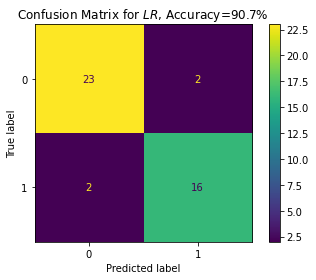

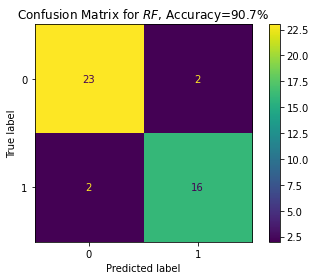

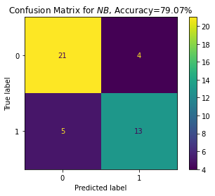

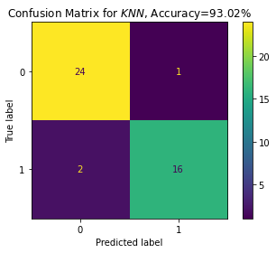

```python
from sklearn.metrics import confusion_matrix,ConfusionMatrixDisplay, accuracy_score

allac=[];
results = [];
for (name, model) in models:
    if (name == 'ANN'):
        y_pred = (ANNmodelOptimized.predict(x_test) > 0.5);
    else:
        y_pred = (model.predict(x_test) > 0.5);
    cm = confusion_matrix((y_test > 0.5), y_pred);
    disp = ConfusionMatrixDisplay(confusion_matrix(y_test,(y_pred)))
    ac = accuracy_score(y_test, y_pred);
    results.append( (name,ac,cm,disp, y_pred) );
    allac.append(ac);


for (name,ac,cm,disp, yp) in results:
    disp.plot();
    plt.title(f'Confusion Matrix for ${name}$, Accuracy={round(ac*100,2)}%');
```

### Single Run Accuracy

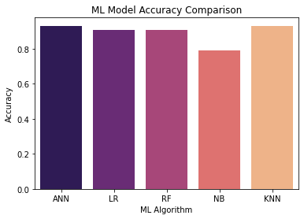

```python
names = [];
for tp in models:
    names.append(tp[0]);

sns.barplot(x=names,y=allac, palette='magma');
plt.title('ML Model Accuracy Comparison');
plt.ylabel('Accuracy');
plt.xlabel('ML Algorithm');
```

## Via K-Fold Cross Validation

```python
# Number of splits to make.
N = 3;

from sklearn import model_selection
from sklearn.model_selection import StratifiedKFold

CV_results = [];
scoring = 'accuracy';

import warnings
warnings.filterwarnings('ignore')
with warnings.catch_warnings():      #Catch warnings in code section
    warnings.simplefilter("ignore")
    for tp in models:
        kfold = StratifiedKFold(n_splits=N, shuffle=True)
        #kfold = model_selection.KFold(n_splits=N);
        CVinternal_results = model_selection.cross_val_score(tp[1], x, y, cv=kfold, scoring=scoring);
        CV_results.append((CVinternal_results));
```

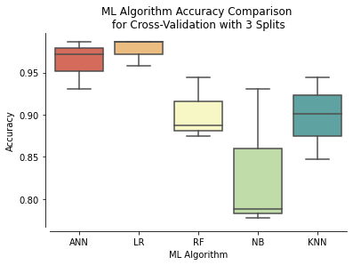

```python
names = [];
for tp in models:
    names.append(tp[0]);

CV_results = pd.DataFrame(CV_results).T;
CV_results.columns = names;

ax2 = sns.boxplot(data=CV_results, palette='Spectral')
ax2.set(xlabel = "ML Algorithm",
       ylabel = 'Accuracy',
       title = f"ML Algorithm Accuracy Comparison \nfor Cross-Validation with {N} Splits");
sns.despine(ax=ax2,offset=5, trim=False)
ax2.plot();
```

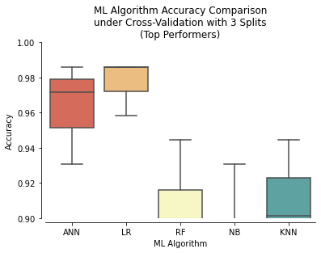

```python
ax3 = sns.boxplot(data=CV_results, palette='Spectral')
ax3.set(xlabel = "ML Algorithm",
       ylabel = 'Accuracy',
       title = f"ML Algorithm Accuracy Comparison\nunder Cross-Validation with {N} Splits\n(Top Performers)");
sns.despine(ax=ax3,offset=5, trim=False)
plt.ylim(0.90,1)
ax3.plot();
```

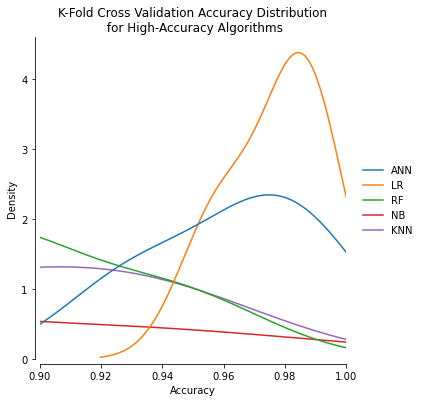

```python
g=sns.displot(data=CV_results, kind='kde');
g.despine(offset=5);
g.set_xlabels('Accuracy');
plt.title('K-Fold Cross Validation Accuracy Distribution\n for High-Accuracy Algorithms');
plt.xlim(0.90,1);
```

# Conclusion

Dimensionality Reduction was performed on the Cancer dataset via Principal Component Analysis (PCA) in order to reduce the number of features from 4000 to 2 and 10 in parts A and B/C respectively. This dimensionality reduction managed to retain 85.775% and 97.216% of the original information (in terms of variance).

> Best Accuracy: 97.092% using {'batch_size': 25, 'epochs': 100, 'neurons': 25, 'optimizer': 'adam'}

Comparison across the models showed that **Logistic Regression** and **ANN** were the best performing of all tested models, achieving accuracies greater than 95% most of the time. Amongst these two, however, LR has a better probability of having a greater accuracy, and in fact is higher than 95% for all tested models. Thus, **LR** can be recommended for deployment for this particular application.